# Network Addresses and Names

## First an Example Network (Ours):

[figure not shown]

## A Farther Look with Some Terms:

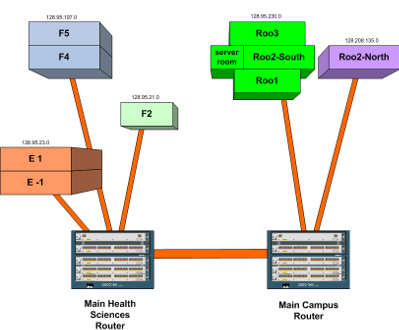

- **LAN**, or **Local**-Area Network
- **WAN**, or **Wide**-Area Network
- **Subnet**, a broader term describing logical subdivisions of a network

## Some Important Addresses

Your computer has various addresses to allow routing of network traffic to and from your computer.

### Hardware (MAC) address

- A non-routable numeric hardware/physical address assigned to your "network interface card" or "NIC"
- an example: 26:a5:b7:20:f0:35

### Internet (IP) Address

- the routable numeric Internet (logical) address assigned to your NIC.
- an example: 128.95.230.32
- This form shows the address under Internet Protocol version 4
- A newer version – IPv6 – is slowly supplanting version 4, but this should not concern you.

## More aboout IP Addresses

- This form (128.95.230.32) shows the address under Internet Protocol version 4 (IPv4).
- A newer version – IPv6 – is slowly supplanting version 4, but this should not concern you.
- IP addresses can be either static or dynamic. Each have different suitabilities.
- The end-to-end use of IP addresses is what allows "routers" to route
- You likely have a router at home.

## Mapping Internet Names to Numbers

### Host Name ("hostname")

- the character-based name assigned to your numeric Internet (IP) address
- often used in short form, like "phage"
- effective use in networking relies on the "fully qualified" name. example: phage.deohs.washington.edu